# Quarto reveal.js clean

A minimalist and elegant presentation theme

Grant McDermott

gmcd@amazon.com

Amazon.com

Kyle Butts

kbutts@uark.edu

U of Arkansas

December 4, 2025

## Example slide

### This is a subtitle

Before we dive a bit deeper, here is a simple example of the [clean theme](https://github.com/grantmcdermott/quarto-revealjs-clean) in action. ss

## Before you proceed…

### Requirements for the coding examples in this demo

The [clean theme](https://github.com/grantmcdermott/quarto-revealjs-clean) is language agnostic. Use it with R, Python, Julia, etc. Or none of the above.

However, this demo uses R code to highlight advanced theme features. You’ll need to install some software if you’d like to render the demo “as-is”.

**Required software (this demo only)**

### R packages

```r
install.packages(c("modelsummary", "fixest", "pdftools", "tinytex", "threejs"))
```

### TinyTex

```bash
quarto install tinytex
```

Note: While the “clean” extension renders to HTML format, this demo includes an example where a LaTeX table can be embedded as an image, which requires [TinyTex](https://quarto.org/docs/output-formats/pdf-engine.html).

# Components

## Components

### Ordered and Unordered Lists

Here we have an unordered list.

- first item
  - sub-item2323
- second item

And next we have an ordered one.

1. first item
   1. sub-item
2. second item

## Components

### Alerts & Cross-refs

To emphasize specific words or text, you can:

- Use the default `.alert` class, e.g. important note.
- Use the `.fg` class for custom colour, e.g. important note.
- Use the `.bg` class for custom background, e.g. important note.

To cross-reference, you have several options, for example:

- Beamer-like `.button` class provided by this theme, e.g. Appendix
- Quarto’s native cross-ref syntax, e.g., “See Section 5.3.”

## Components

### Citations

Citations follow the standard [Quarto format](https://quarto.org/docs/authoring/footnotes-and-citations.html#citations) and be sourced from BibLaTex, BibTeX, or CLS files. For example:

- Topic 1: Spatial Frictions (Fajgelbaum et al. 2018; Hsieh and Moretti 2019; Moretti 2011)
- Topic 2: Blah (Suárez Serrato and Zidar 2016)

## Components

### Mathematics

Use inline ($\alpha$, $\pi$) or display math as needed:

$$P(E) = {n \choose k} p^k (2-p)^{n-k} \int^\infty_0 x dx$$

P.S. Quarto provides dedicated [math environments](https://quarto.org/docs/authoring/cross-references.html#theorems-and-proofs) for theorems, lemmas, etc. But for presentations, it’s easier just to highlight via a [callout block](https://quarto.org/docs/authoring/callouts.html).

**Regression specification**

$$y_{it} = X_{it} \beta + \mu_i + \varepsilon_{it}$$

## Components

### Multicolumn I: Text only

Here is a long sentence that will wrap onto the next line as it hits the column width, and continue this way until it stops.

Some other text in another column.

A second paragraph.

Multicolumn support is very flexible and we can continue with a single full span column in the same slide.

## Components

### Multicolumn II: Text and figures

[figure not shown]

- A point about the figure that is potentially important.
- Another point about the figure that is also potentially important.

Note that sub- and multi-panel figures are also natively supported by Quarto. See [here](https://quarto.org/docs/authoring/figures.html#subfigures).

## Components

### Multicolumn III: Code and output

```r
palette("Classic Tableau")

par(
  family = "HersheySans",
  las = 1, pch = 19, cex = 1.5
)

pairs(
  iris[,1:4],
  col=iris$Species
)
```

[figure not shown]

Figure 1: Pairwise scatterplot

# Tables

## Markdown tables

### Default table styling

The `clean` theme rolls its own minimalist aesthetic for tables. This should interface directly with Quarto’s excellent [table support](https://quarto.org/docs/authoring/tables.html).

```markdown
| fruit  | price  |
|--------|-------:|
| apple  | 2.05   |
| pear   | 1.37   |
| orange | 3.09   |

: Fruit prices {tbl-colwidths="[75,25]"}
```

Fruit prices

| fruit | price |
| --- | --- |
| apple | 2.05 |
| pear | 1.37 |
| orange | 3.09 |

## Regression tables

### Regression example

These aesthetics should carry over to any computation-based tables too.

Let’s take a few slides to illustrate via a simple regression example:

```r
library(fixest)

mods = feols(
  rating ~ complaints + privileges + learning + csw0(raises + critical),
  data = attitude
)

dict = c("rating"     = "Overall Rating",
         "complaints" = "Handling of Complaints",
         "privileges" = "No Special Priviledges",
         "learning"   = "Opportunity to Learn",
         "raises"     = "Performance-Based Raises",
         "critical"   = "Too Critical")
```

## Regression tables

### modelsummary

Regression table software should play nice with this theme out the gate. Here’s a [modelsummary](https://modelsummary.com/) example.

```r
library(modelsummary)

modelsummary(
  setNames(mods, c("(1)", "(2)")),
  coef_map = dict, stars = TRUE,
  gof_map = NA
  ) |>
  # some optional stylistic tweaks
  tinytable::group_tt(j = list("Dep. variable: Overall Rating" = 2:3)) |>
  tinytable::style_tt(i = 1:2, j = 2:3, background = "pink")
```

(The table is displayed on the next slide.)

## Regression tables

|  | Dep. variable: Overall Rating (1) | Dep. variable: Overall Rating (2) |
| --- | --- | --- |
| Handling of Complaints | 0.682*** | 0.692*** |
|  | (0.129) | (0.149) |
| No Special Priviledges | -0.103 | -0.104 |
|  | (0.129) | (0.135) |
| Opportunity to Learn | 0.238+ | 0.249 |
|  | (0.139) | (0.160) |
| Performance-Based Raises |  | -0.033 |
|  |  | (0.202) |
| Too Critical |  | 0.015 |
|  |  | (0.147) |

+ p < 0.1, * p < 0.05, ** p < 0.01, *** p < 0.001

## Regression tables

### fixest::etable

**Aside:** We estimated our models with [fixest](https://lrberge.github.io/fixest/), which bundles its own powerful `etable` function. While `etable` was designed for LaTeX output, it can be [incorporated](https://lrberge.github.io/fixest/articles/etable_new_features.html) into HTML Quarto too.<sup>1</sup>

- Set the `output: asis` R chunk option in your Quarto doc.
- Set the `setFixest_etable(markdown = TRUE)` option.

````markdown
```{r}
#| output: asis

setFixest_etable(markdown = TRUE, drop = "Constant")
setFixest_dict(dict)

etable(mods, highlight = .("se" = "complaints"))
```
````

[^1]: You will need to install the `tinytex` & `pdftools` packages first.

## Regression tables

### fixest::etable (cont.)

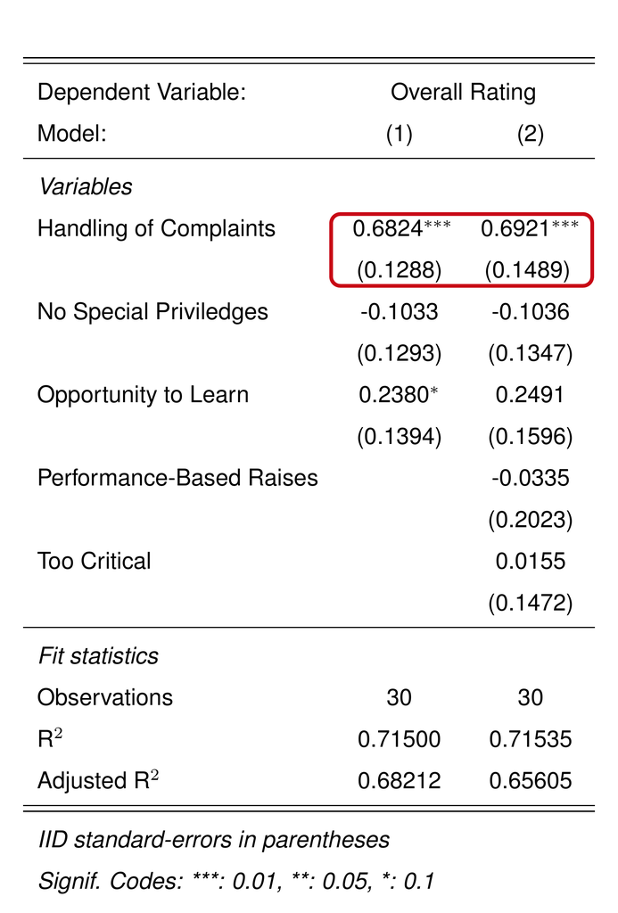

# Figures

## Figures

### Automatic scaling

We’ve already seen examples of code-generated plots and mulicolumn figures. But a reminder that figures will auto-scale with the available space.

[figure not shown]

## Figures

### Backround images

You can use the `{.background-image}` container environment to completely fill the slide background with an image.

Ideally, your figure will be the same aspect ratio as the screen that you’re presenting on.

- This can be a bit tricky because of the dynamic nature of reveal.js / HTML. But it’s probably something close to 16:9.
- Aspect ratio can also matter for a regular full-frame images (previous slide).

## Interactive plots

[interactive chart not shown]

*Note: Simple flight data example using `threejs`. There are many interactive plotting options beyond this. (More [details](https://quarto.org/docs/interactive/).)*

# Other

## Other

### What else can the clean theme do?

We have highlighted some theme-specific components in this demo.

But please note that all of the standard [reveal.js functionality and plugins](https://quarto.org/docs/presentations/revealjs/presenting.html) are compatible with the clean theme. This includes:

- chalkboard for annotating slides.
- multiplex for enabling audience navigation of your slides.
- [pdf printing](https://quarto.org/docs/presentations/revealjs/presenting.html#print-to-pdf) in case you don’t have access to a web browser.
- Etc.

# Summary

## Summary

### A minimalist and elegant presentation theme

Add the theme to an existing project.

```bash
quarto install extension grantmcdermott/quarto-revealjs-clean
```

… or, create a new project using our lean template.

```bash
quarto use template grantmcdermott/quarto-revealjs-clean
```

… or, create a new project using these demo slides as a full template.

```bash
quarto use template grantmcdermott/quarto-revealjs-clean-demo
```

## References

Fajgelbaum, Pablo D, Eduardo Morales, Juan Carlos Suarez Serrato, and Owen Zidar. 2018. “State Taxes and Spatial Misallocation,” 90.

Hsieh, Chang-Tai, and Enrico Moretti. 2019. “Housing Constraints and Spatial Misallocation.” *American Economic Journal: Macroeconomics* 11 (2): 39.

Moretti, Enrico. 2011. “Local Labor Markets.” In *Handbook of Labor Economics*. Vol. 4. Elsevier.

Suárez Serrato, Juan Carlos, and Owen Zidar. 2016. “Who Benefits from State Corporate Tax Cuts? A Local Labor Markets Approach with Heterogeneous Firms.” *American Economic Review* 106 (9).

## Appendix

Table 1: Summary of the base R `attitude` dataset

Unique

Missing Pct.

Mean

SD

Min

Median

Max

Histogram

rating

22

0

64.6

12.2

40.0

65.5

85.0

[figure not shown]

complaints

23

0

66.6

13.3

37.0

65.0

90.0

[figure not shown]

privileges

24

0

53.1

12.2

30.0

51.5

83.0

[figure not shown]

learning

23

0

56.4

11.7

34.0

56.5

75.0

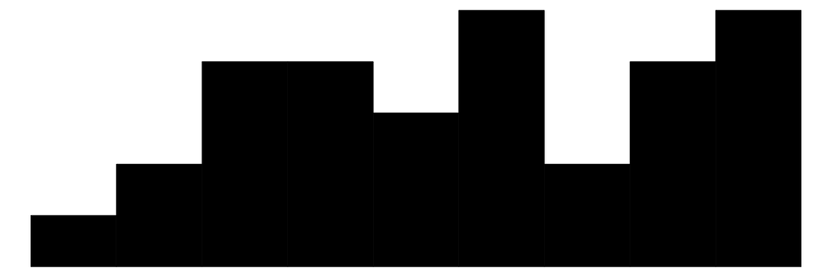

raises

21

0

64.6

10.4

43.0

63.5

88.0

[figure not shown]

critical

21

0

74.8

9.9

49.0

77.5

92.0

[figure not shown]

advance

20

0

42.9

10.3

25.0

41.0

72.0

[figure not shown]

Back to main